# DATA2x02_survey_2023

Author

510508678

Published

September 10, 2023

## 1 Data Wrangling

All calculations in the report were performed in **R**(R Core Team 2023) within the **Quarto** environment. (Allaire et al., 2022). Data Wrangling was performed using R and **tidyverse** library (Wickham et al. 2019). All graphs were produced by **ggplot2** (Wickham et al. 2019), tables were produced with **gt** (Iannone et al., 2023) and formatted by **gridExtra** (Auguie & Antonov, 2017) .

Before conducting further analysis on the data, it is important to test whether the sample was iid. The sample might not be independent as the survey questions were not required to be completed individually within a time limit. This could result some students who completed the survey influenced the students who did not. The sample was identically distributed as all observations within the sample came from the survey. However, in the following hypothesis, it was still assumed that the sample was iid.

## 2 Data Cleaning

All variable names were shortened and some varaibles in the raw data were cleaned with DATA2002 assignment: data importing and cleaning guide (Tarr,G. 2023). Varaiable gender, wam and social_meida_hrs were cleaned to contain either valid data or NA. And outliers were converted to NA to prevent distortion of the true distribution of data and ensure test accuracy

### 2.1 Gender

Use package on github called gendercoder to categorize raw data in to three categories, NA, man and woman. However, one response- “Women” was accidentally categorized into NA category with recode_gender. So, it needed an additional step to convert it back into woman category.

### 2.2 WAM

All cells in wam are numeric, but wam can not be smaller or equal to 0 and can not be larger than 100. So, for answers that did not fall into the region $0 < \text{wam} < 100$ were converted into NA. Furthermore, outliners were remove using formula:

$$\text{Outliers} = \text{Values} < Q1 - 1.5 \times IQR \text{ or } \text{Values} > Q3 + 1.5 \times IQR$$

### 2.3 Social_Media_Hrs

Though all cells are numeric and larger than 0. But some data were larger or equal to 24 hours. These data were not valid as there was only 24 hours a day and human needed sleep. Thus, all data that were larger or equal to 24 were converted to NA.

## 3 General discussion of the data as a whole

### 3.1 Is this a random sample of DATA2X02 students?

The raw data is collected from the anonymous survey on Ed which is available to all DATA2x02 students. All questions are optional and there is no requirement to fill out the survey.(DATA2x02_survey_2023) This data set does not represent a random sample of DATA2X02 students. In a random sample, each individual from a population has an identical probability of being chosen. However, in this case, only students who responded to the survey have a chance of being chosen, while students who did not have no chance. Therefore, not all students in the DATA2X02 have an equal probability of being chosen, indicating that the data was not obtained through random sampling. However, for the convenience of the following analysis, we assumed the sample was random and iid.

### 3.2 What are the potential biases? Which variables are most likely to be subjected to this bias?

1. **Self-selection Bias:**

   Since the survey was posted on Ed and opened to all DATA2X02 students, but questions were optional. There’s a probability that only students who were interested in the survey questions choose to participate. This might result in an unrepresentative sample, as students who were interested in the survey questions might share certain perspectives or characteristics ,potentially overshadowing other diverse characteristics.. In this case, all variables in the survey were experiencing self-selection bias as students can choose whether they do the survey or not.
2. **Non-response Bias:**

   Given the survey was optional and not all students responded to every question in the survey. If students who did not respond to the survey have different opinions, then non-respond bias is introduced. For questions like What’s your WAM, team role there’s the probability that students with a higher WAM a more likely to respond to this WAM question. And free riders may not answer the team role question. This can lead to a higher WAM average in the sample, which can not represent the actual population.

### 3.3 Which questions needed improvement to generate useful data (e.g. in terms of the way the question was phrased or response validation)?

**What is your WAM?**

The questions asked students to provide the Weighted average mark they have got. However, not everyone knows what “WAM” stands for. Consider spelling out the acronym helps students to understand the question and generate more accurate results.

**What brand is your laptop?**

The question can be improved by offering predefined answers. As students might refer to the same brand in different ways. For example, Apple laptops might be written as “Mac”,” Mac book”, or “Apple”. This can lead to fragmented data where the same brands appear as multiple categories. Thus, offering predefined ensures the consistency of responses and reduces the chances of varied responses for the same brand.

```r
library(gt)
library(dplyr)
library(tidyverse)
library(gridExtra)

x = readr::read_csv("data/DATA2x02 survey (2023) (Responses) - Form responses 1.csv")
old_names = colnames(x)
new_names = c("timestamp","n_units","task_approach","age",
              "life","fass_unit","fass_major","novel",
              "library","private_health","sugar_days","rent",
              "post_code","haircut_days","laptop_brand",
              "urinal_position","stall_position","n_weetbix","food_budget",
              "pineapple","living_arrangements","height","uni_travel_method",
              "feel_anxious","study_hrs","work","social_media",
              "gender","sleep_time","diet","random_number",
              "steak_preference","dominant_hand","normal_advanced","exercise_hrs",
              "employment_hrs","on_time","used_r_before","team_role",
              "social_media_hrs","uni_year","sport","wam","shoe_size")
# overwrite the old names with the new names:
colnames(x) = new_names
# combine old and new into a data frame:
name_combo = bind_cols(New = new_names, Old = old_names)
x = x |>
  dplyr::mutate(
    height_clean = suppressWarnings(readr::parse_number(height)),
    height_clean = case_when(
      # convert meters to cm
      height_clean <= 2.5 ~ height_clean * 100,
      # convert the feet and inches to missing
      height_clean <= 9 ~ NA_real_,
      # convert inches to cm
      height_clean < 90 ~ height_clean * 2.54,
      TRUE ~ height_clean
    )
  )

x = x |>
  mutate(social_media_hrs_clean = ifelse (social_media_hrs >=24,NA,social_media_hrs))
```

## 4 Hypothesis tests

### 4.1 Is academic performance independent to gender?

To test the academic performance of different gender groups — Male, Female and Potential genders. WAM is classified into two categories — above of equals to 75 or below 75. Students with a NA value of WAM is excluded as NA can not fall into either category. However, NA value in gender have been recorded as Potential genders. This categorization offers insights into gender dynamics, as an undefined gender could represent non-binary individuals or those who identify as male or female but chose not to specify. The bar chars in Figure2 show the number of students who achieved WAM 75 equal or above and those below 75 in all three gender groups.

```r
# ADD a new collumn wam_d_above fill with true when wam above or equal to 75 and fill false when the wam is below (independence test)
x=x |>  mutate(
    gender_clean = gendercoder::recode_gender(gender),
    gender_clean = ifelse(gender == "Women","woman",gender_clean),
    wam = ifelse(wam <= 0 | wam > 100, NA, wam),
    wam_d_above = wam >= 75,
    wam_d_above = factor(wam_d_above, levels = c(TRUE, FALSE)),
    gender_clean = factor(gender_clean, levels = c("man", "woman"))
  )


gender_wam = table(x|>filter(!is.na(wam_d_above))|> select(gender_clean) |> pull(), x |> filter(!is.na(wam_d_above))|> select(wam_d_above) |> pull(),useNA = "ifany")
colnames(gender_wam)= c("WAM above or equal to 75","WAM below 75")
rownames(gender_wam)= c("Male","Female","Potential genders")

wam_df = data.frame(Gender = c('Male','Female','Potentail gender'),
                    "WAM above or equal to 75" = gender_wam [ ,1],
                    "WAM below 75" = gender_wam [ ,2])
colnames(wam_df) = c('Gender',"WAM above or equal to 75","WAM below 75")
wam_df|>
gt::gt() |>
  gt::fmt_number(columns = everything(),decimals = 0)
```

| Gender | WAM above or equal to 75 | WAM below 75 |
| --- | --- | --- |
| Male | 83 | 70 |
| Female | 46 | 38 |
| Potentail gender | 7 | 4 |

<sup>Figure1: students are classified according to their gender and their WAM</sup>

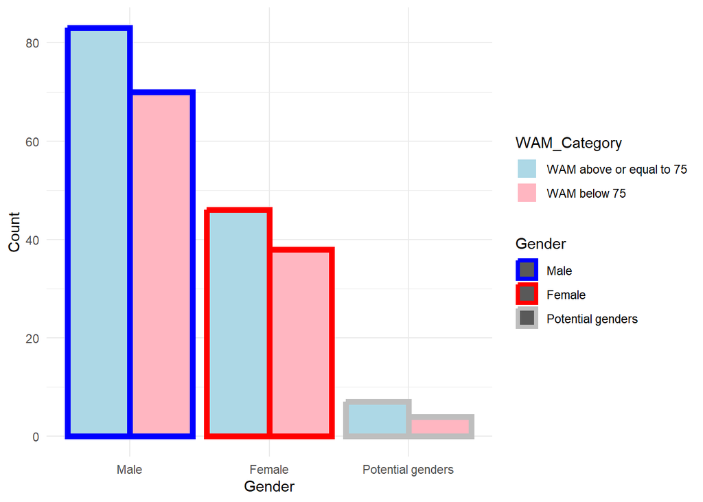

```r
gender_wam_long = as.data.frame(as.table(gender_wam))
colnames(gender_wam_long) = c("Gender", "WAM_Category", "Count")

# Plot using ggplot2
ggplot(gender_wam_long, aes(x = Gender, y = Count, fill = WAM_Category,, colour = Gender)) +
  geom_bar(stat = "identity", position = "dodge",linewidth = 2) +
  labs(

       x = "Gender",
       y = "Count") +
  scale_fill_manual(values = c("lightblue", "lightpink")) +
   scale_color_manual(values = c("blue","red","grey"))+
  theme_minimal()
```

<sup>Figure2: Distribution of WAM in gender groups.</sup>

Check the assumption of independence $\chi^2$ test : $e_{ij} = \frac{Y_i - e_i}{e_i} \geq 5$

```r
test_result = suppressWarnings(chisq.test(gender_wam))
t_r = test_result$expected |> data.frame()|> mutate( Gender =c("Male","Female","Potential Genders") )
colnames(t_r)=c("WAM above or equal to 75","WAM below 75","Gender")
t_r|>
gt::gt() |> cols_move_to_start(columns = "Gender")|>
  gt::fmt_number(columns = everything())
```

| Gender | WAM above or equal to 75 | WAM below 75 |
| --- | --- | --- |
| Male | 83.90 | 69.10 |
| Female | 46.06 | 37.94 |
| Potential Genders | 6.03 | 4.97 |

<sup>Figure3: Expected value for the contingency table of WAM in gender groups.</sup>

The expected value for number of students achieved WAM below 75 in Potential genders is less than 5 which violates with the previous assumption. Therefore, Morte Carlo test was used instead.

```r
chisq = test_result$statistic
row_totals = rowSums(gender_wam)
col_totals = colSums(gender_wam)
B = 10000
set.seed(123)
x_list = r2dtable(n = B,
                  r = row_totals,
                  c = col_totals)
rnd.chisq = numeric(B)
for (i in 1:B){
  rnd.chisq[i] = suppressWarnings(chisq.test(x_list[[i]])$statistic)
}
result = sum(rnd.chisq >= chisq)/B
result_p = chisq.test(gender_wam, simulate.p.value = TRUE, B = 10000)

# The test result for manual calculation was 0.8763 and result generate by chisq.test was 0.8789. The result was similar and as they both above 0.05 we did not reject the null hypothesis
```

1. **Hypotheses:**

- $H_0$: Gender is independent of whether a student achieved a WAM above or equal to 75
- $H_1$: Gender and whether a student achieved a WAM above or equal to 75 are not independent

2. **Assumptions**: No assumptions are made about the underlying distribution of the population and the estimated value. The sample is iid.

3. **Test statistic**: $T = \sum_{i=1}^{k} \frac{(Y_i - e_i)^2}{e_i} \sim \chi^2_2$.

4. **Observed test statistic**: $t_0$ = 0.3655

5. **p-value**: $P(\chi^2_2 \geq$ 0.3655$)$ = 0.8763

6. **Decision**: Since the p-value is close to 1, there is not sufficient evidence to reject the null hypothesis. Gender is independent to whether a student could achieve WAM equal or above 75.

### 4.2 Are the mean of WAM for female and male the same in DATA2X02 ?

To determine whether there’s a difference in the mean WAM between males and females in Data2X02, we conducted a two-sample t-test.The test assumes the sample mean followed an normal distribution. In this case the assumption was true as the sample roughly followed a normal distribution in Figure 4. The sample size was larger than 30 by Central Limited theorem the sample mean is normally distributed.

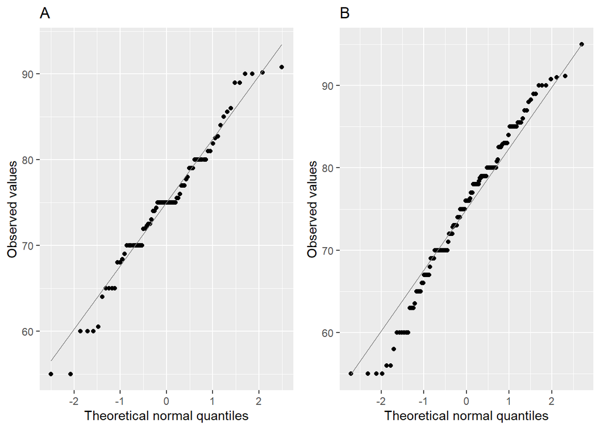

```r
# Calculate Q1, Q3, and IQR for the 'value' column
Q1 = x|> filter(!is.na(x$wam))|> select(wam) |>  pull()|> quantile( 0.25)
Q3 = x|> filter(!is.na(x$wam))|> select(wam) |> pull()|>quantile( 0.75)
IQR = Q3 - Q1


f_wam = x|>filter(gender_clean =='woman' & !is.na(wam)& wam >= (Q1 - 1.5 * IQR) & wam <= (Q3 + 1.5 * IQR)) |> select(c(wam,gender_clean))
m_wam =  x|>filter(gender_clean =='man' & !is.na(wam)& wam >= (Q1 - 1.5 * IQR) & wam <= (Q3 + 1.5 * IQR)) |> select(c(wam,gender_clean))

q_f = f_wam |> ggplot(aes(sample=wam)) +
  geom_qq() +
  geom_qq_line(color = grey(0.5)) +
  labs(x = "Theoretical normal quantiles",
       y = "Observed values",
       title = "A")
q_m =m_wam |> ggplot(aes(sample=wam)) +
  geom_qq() +
  geom_qq_line(color = grey(0.5)) +
  labs(x = "Theoretical normal quantiles",
       y = "Observed values",
       title = "B")
grid.arrange(q_f, q_m, ncol=2)
```

<sup>Figure 4: QQ plots for WAM showing a roughly normal distribution of two sample groups. **A**: WAM in female **B**: WAM in male</sup>

[figure not shown]

```r
b_f = ggplot(m_wam, aes(x=gender_clean, y=wam,colour = gender_clean)) +
  geom_boxplot() +
  geom_jitter(aes(color=gender_clean), width=0.2, size=2) +
  labs( title = "A",x="Female", y="WAM") +
  theme(axis.text.x = element_blank())+
  scale_color_manual(values="#FF9999")


b_m = ggplot(m_wam, aes(x=gender_clean, y=wam,colour = gender_clean)) +
  geom_boxplot() +
  geom_jitter(aes(color=gender_clean), width=0.2, size=2) +
  labs( title = "B", x="Male", y="WAM") +
  theme(axis.text.x = element_blank())+
  scale_color_manual(values="#66B2FF")

grid.arrange(b_f, b_m, ncol=2)
```

```r
f_m_wam = data.frame(
  Status = c("WAM for Female", "WAM for Male"),
  Mean = c(mean(f_wam$wam), mean(m_wam$wam)),
  StandardDeviation = c(sd(f_wam$wam), sd(m_wam$wam)),
  N = c(nrow(f_wam),nrow(m_wam))

)

gt::gt(f_m_wam) |>
  gt::fmt_number(columns = c("Mean","StandardDeviation"), decimals =2)
```

| Status | Mean | StandardDeviation | N |
| --- | --- | --- | --- |
| WAM for Female | 74.80 | 7.91 | 79 |
| WAM for Male | 75.03 | 8.82 | 145 |

<sup>Figure 6: Mean, Standard Deviation , number of observations for Female’s WAM and Male’s WAM.</sup>

```r
t_sample = t.test(f_wam$wam, m_wam$wam,
       alternative = "two.sided", var.equal =  TRUE)
```

1. **Hypotheses:**

- $H_0$: The mean WAM of the DATA2X02 female group is equal to the mean WAM of the DATA2X02 male group.
- $H_1$: The mean WAM of the DATA2X02 female group is different to the mean WAM of the DATA2X02 male group.

2. **Assumptions**: The two sample mean followed a normal distribution. And the two sample are independent and contain identically distributed random variables. The population have equal variance.

3. **Test statistic**: $T$ = $\frac{\bar{X}_F - \bar{X}_M}{ \sqrt{\frac{S_P}{n_F} + \frac{S_P}{n_M}}}$ where $n_F$ =79, $n_M$ = 145 , $S_F^2$ and $S_M^2 .$ are the sample variance of WAM for female and WAM for male. $S_p$ = $\sqrt{\frac{(n_F-1)S_F^2 +(n_M-1)S_M^2}{n_F+n_M-2}}$Under $H_0$ , $T$ ~ $t_{n_F+n_M-2}$

4. **Observed test statistic**: $t_0 =$ -0.1962

5. **p-value**: $2P(t_v \geq |$-0.1962$|) =$ 0.8446

6. **Decision**: Since the p-value is close to 1, there is not sufficient evidence to reject the null hypothesis. The population mean of WAM in DATA2X02 female group is the same with the population mean of WAM in DATA2X02 male group.

### 4.3 Is academic performance independent to social media usage?

Similar to our initial hypothesis, we categorized WAM into two groups: those scoring 75 or higher, and those scoring below 75. Students without a WAM were not considered. To examine social media usage. Previous research suggested that on average people used social media 2.5 hours per day. Therefore we used 2.5 hours as a critical value to categorize social media usage – Use social media a lot (above 2.5 hours ), Use social media less often (below 2.5 hours). We excluded entries with missing data on social media usage, as they couldn’t be categorized accurately.

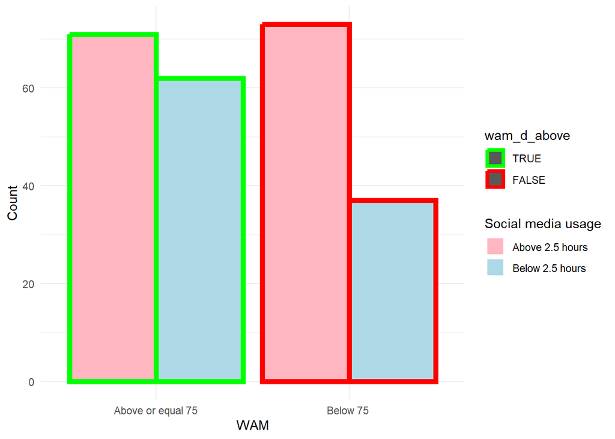

```r
x = x |>
  mutate(
    s_m_usage = ifelse(social_media_hrs_clean >2.5 , "Use social media a lot", "Use social media less often"),
    factor(s_m_usage, levels = c("Use social media a lot", "Use social media less often"))
         )
y = data.frame(
  wam_d_above = x$wam_d_above,
s_m_usage=x$s_m_usage
  )
y=drop_na(y)

ggplot(data = y, aes(x = wam_d_above, fill =s_m_usage,colour = wam_d_above  )) +
  geom_bar(position = "dodge",linewidth = 2) +
   scale_x_discrete(labels = c("TRUE" = "Above or equal 75", "FALSE" = "Below 75 "))+
  labs(x = "WAM", y = "Count", fill = "Social media usage") +
  scale_fill_manual(values = c("Use social media a lot" = "lightpink", "Use social media less often" = "lightblue"),labels = c("Above 2.5 hours", "Below 2.5 hours")) +
  scale_color_manual(values = c("green","red"))+


  theme_minimal()
```

<sup>Figure 7: The distribution of social media usage in WAM groups.</sup>

```r
freq_table <- table(x$wam_d_above, x$s_m_usage)
freq_table |> rownames()= c("WAM above or equal to 75","WAM below 75")

sm_df = data.frame(WAM = c('75 above or equal','Below 75'),
                    "Use social media a lot" = freq_table [ ,1],
                    "Use social media less often" = freq_table [ ,2])
colnames(sm_df) = c("WAM","Use social media a lot", "Use social media less often")
rownames(sm_df) = c('75 above or equal','Below 75')
sm_df|>
gt::gt()
```

| WAM | Use social media a lot | Use social media less often |
| --- | --- | --- |
| 75 above or equal | 71 | 62 |
| Below 75 | 73 | 37 |

<sup>Figure 8: Students are group according to WAM and social media usage.</sup>

Since the observed value in Figure 9 has been larger than 5. A $\chi^2$ test could be valid for the independence test.

```r
independece_test = chisq.test(freq_table, correct = FALSE)
t_r = independece_test$expected |> data.frame()|> mutate( WAM = c('75 above or equal','Below 75') )
colnames(t_r)=c("Use social media a lot","Use social media less often","WAM")
t_r|>
gt::gt() |> cols_move_to_start(columns = "WAM")|>
  gt::fmt_number(columns = everything())
```

| WAM | Use social media a lot | Use social media less often |
| --- | --- | --- |
| 75 above or equal | 78.81 | 54.19 |
| Below 75 | 65.19 | 44.81 |

<sup>Figure 9: Expected value for contingency table.</sup>

1. **Hypotheses:**

- $H_0$: Social media usage and whether a student achieved a WAM above or equal to 75 are independent
- $H_1$: Social media usage and whether a student achieved a WAM above or equal to 75 are not independent

2. **Assumptions**: expected value in each cell larger than 5. $e_{ij} = \frac{Y_i - e_i}{e_i} \geq 5$ The sample is iid.

4. **Observed test statistic**: $t_0 =$ 4.2016

## 5 Conclusion

The tests above tested the how WAM are related to gender and social media usage and the whether the mean of WAM in male and female are equal. Under the assumption of the data generated by the survey was random and iid.

We concluded that gender and WAM were independent, the mean of WAM in male and female are roughly equal.

One caveat for the tests: the data generated by a optional survey with no time limit and completing restrictions wast not random and might not be iid. Therefore, the data could be bias and generate inaccurate results.

## 6 References

Allaire, J.J., Teague, C., Scheidegger, C., Xie, Y., & Dervieux, C. (2022, January). Quarto (Version 1.2). DOI: 10.5281/zenodo.5960048

Auguie, B., & Antonov, A. (2017). *gridExtra: Miscellaneous Functions for “Grid” Graphics* (R package version 2.3) https://CRAN.R-project.org/package=gridExtra

R Core Team. 2023. *R: A Language and Environment for Statistical Computing*. Vienna, Austria: R Foundation for Statistical Computing. [https://www.R-project.org/](https://www.r-project.org/).

Wickham, Hadley, Mara Averick, Jennifer Bryan, Winston Chang, Lucy D’Agostino McGowan, Romain François, Garrett Grolemund, et al. 2019. “Welcome to the tidyverse.” *Journal of Open Source Software* 4 (43): 1686. https://doi.org/10.21105/joss.01686.

Xie, Yihui, J. J. Allaire, and Garrett Grolemund. 2018. *R Markdown: The Definitive Guide*. Boca Raton, Florida: Chapman; Hall/CRC. https://bookdown.org/yihui/rmarkdown.

Tarr, G. (2023). DATA2002 assignment: data importing and cleaning guide. Retrieved August 23, 2023,from https://pages.github.sydney.edu.au/DATA2002/2023/assignment/assignment_data.html